# Analise Vinhos Tintos

# Análise Multivariada

### Discuta sobre os relacionamentos observados nesta parte da investigação. Quais atributos que fortaleceram os demais na observação das variáveis de interesse?

Existem substancias no vinho que tem relação com a qualidade do vinho e outras que não podemos ver que algumas são independentes de outras e outras dependentes. Isso pode ser importante na hora de fazer o blend de um vinho tinto. Maoria dos vinhos hoje comerciais são ajustados quimicamente (com diferentes uvas).

### OPCIONAL: Modelos foram criados usando este conjunto de dados? Discuta sobre os pontos fortes e as limitações do seu modelo.

Modelo com R^2 baixo. Talvez mais tempo para adaptar ou filtrar o dataset dos outliers.

```
##
## Calls:
## m1: lm(formula = I(top) ~ I(alcohol.trans), data = df_vinho.sub)
## m2: lm(formula = I(top) ~ I(alcohol.trans) + sulphates, data = df_vinho.sub)
## m3: lm(formula = I(top) ~ I(alcohol.trans) + sulphates + volatile.acidity.trans,
##     data = df_vinho.sub)
## m4: lm(formula = I(top) ~ I(alcohol.trans) + sulphates + volatile.acidity.trans +
##     citric.acid, data = df_vinho.sub)
## m5: lm(formula = I(top) ~ I(alcohol.trans) + sulphates + volatile.acidity.trans +
##     citric.acid + chlorides, data = df_vinho.sub)
## m6: lm(formula = I(top) ~ I(alcohol.trans) + sulphates + volatile.acidity.trans +
##     citric.acid + chlorides + fixed.acidity, data = df_vinho.sub)
##
## ========================================================================================================
##                               m1           m2           m3           m4           m5           m6
## --------------------------------------------------------------------------------------------------------
##   (Intercept)                5.646***     5.794***     4.595***     4.459***     4.335***     4.716***
##                             (0.266)      (0.261)      (0.285)      (0.290)      (0.294)      (0.306)
##   I(alcohol.trans)          -2.215***    -2.130***    -1.923***    -1.916***    -1.843***    -1.932***
##                             (0.113)      (0.112)      (0.111)      (0.111)      (0.115)      (0.116)
##   sulphates                              -0.525***    -0.374***    -0.408***    -0.477***    -0.462***
##                                          (0.065)      (0.066)      (0.067)      (0.072)      (0.072)
##   volatile.acidity.trans                               0.858***     0.994***     0.928***     1.019***
##                                                       (0.092)      (0.108)      (0.111)      (0.113)
##   citric.acid                                                       0.164*       0.123        0.383***
##                                                                    (0.068)      (0.070)      (0.093)
##   chlorides                                                                      0.657*       0.486
##                                                                                 (0.265)      (0.266)
##   fixed.acidity                                                                              -0.036***
##                                                                                              (0.009)
## --------------------------------------------------------------------------------------------------------
##   R-squared                  0.193        0.224        0.264        0.267        0.270        0.278
##   adj. R-squared             0.192        0.223        0.263        0.265        0.267        0.275
##   sigma                      0.448        0.440        0.428        0.428        0.427        0.425
##   F                        381.244      230.758      190.943      145.084      117.678      102.110
##   p                          0.000        0.000        0.000        0.000        0.000        0.000
##   Log-likelihood          -985.519     -953.606     -911.349     -908.452     -905.361     -896.376
##   Deviance                 321.156      308.589      292.702      291.644      290.518      287.272
##   AIC                     1977.039     1915.213     1832.699     1828.905     1824.723     1808.753
##   BIC                     1993.170     1936.721     1859.584     1861.167     1862.363     1851.770
##   N                       1599         1599         1599         1599         1599         1599
## ========================================================================================================
```

# Gráficos Finais e Sumário

### Primeiro Gráfico

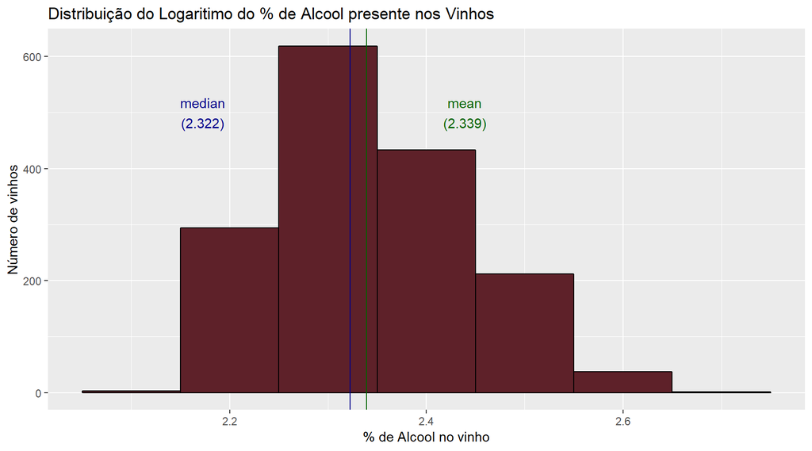

### Descrição do Primeiro Gráfico

Gráfico da distribuição transformada do percentual de alcool encontrada nos vinhos da amostra. Foi adcionada duas linha verticais com a media e a mediana desse distribuição.

### Segundo Gráfico

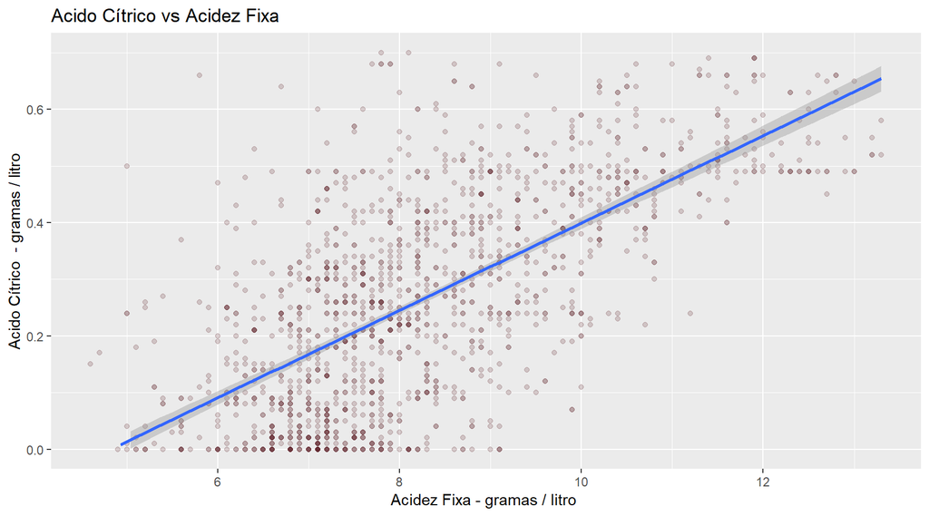

### Descrição do Segundo Gráfico

O segundo gráfico, Acido Citrico x Acidez fixa mostra uma relação forte podendo considera-las variaveis dependentes. O que faz sentido porque estão relacionada a acidez.

### Terceiro Gráfico

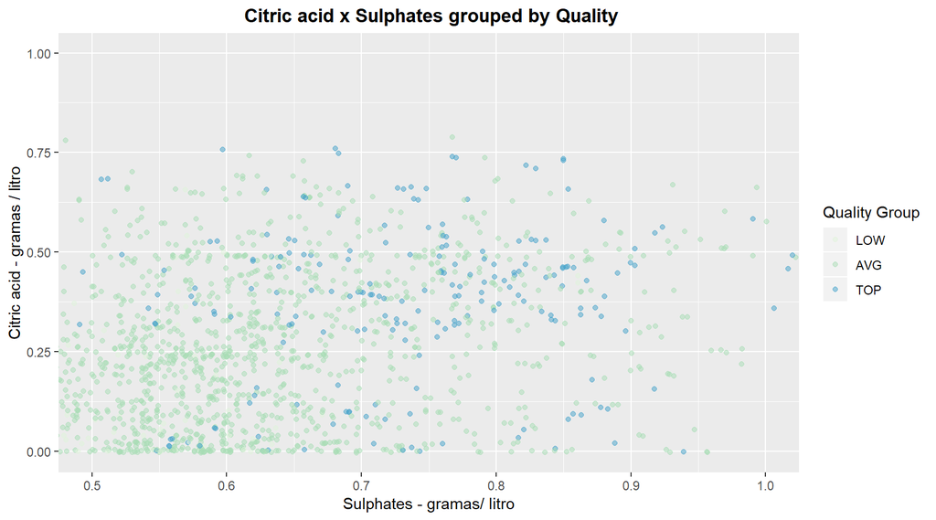

### Descrição do Terceiro Gráfico

Gráfico Acido Citrico x Sulfatos agrupado pela qualidade do vinho. Pelo gráfico podemos ver uma relação entre a qualidade do vinho e as variaveis. Quanto maior o acido citrico maior a qualidade e quanto maior os sulfatos tambem. A quantidade de sulfatos e acido citrico parecem ser independentes também.

# Reflexão

Pelos dados que temos podemos notar que a qualidade de um vinho tinto não depende exclusivamente de uma ou poucas variaveis. Ficou muito dificil prever a qualidade de um vinho somente pela propriedades quimicas que temos nos nossos atributos. Talvez quando comparado entre safras diferentes ou mesmo tipo de uva esses atributos possam criar modelos com boa chances de uma previsão acertada. Seria interessante ter mais dados e mais atributos. O preço também é um determinante importante. E ter uma visão melhor de como foi feito a qualificação dos vinhos seria interessante pois o ambiente a época a temperatura pode influenciar bastante no resultado. O interessante do projeto foi rever todos os conceitos dado no curso de EDA e aprender mais bibliotecas em R. O que achei mais desafiador no projeto foi lidar com uma quantidade enorme de atributo. Muito atributos com outliers também. Talvez devesse fazer uma limpeza melhor dos dados. Outro fator que é desafiador também é quando não fazemos parte do processo de coleta dos dados. Não modelamos como seria feito. O que de certa maneira nos torna mais sujeitos a erros. Para mim o aprendizado mais relevante foi lidar com a ferramenta R. Praticamente usando python e nos ultimos 6 meses power Bi. Desde aprender sobre as bibliotecas como usar o R Studio inclusive para publicar no GitHub. Em relação aos gráficos também fui muito legal aprender sobre os geoms do ggplot2, muitas possibilidades de visualização que posso usar no futuro.